# MA415_FinalProject

# Description:

Now is the season for NBA. Living in Boston, I want to see how Boston Celtics plays in this season. Recently, they have games with Philadelphia 76ers. Let’s see how they are doing so far.

# Data used:

I developed my own twitter Api and get the tweets and write in files such as celticsbefore.csv, celticsafter.csv, ssixersbefore.csv and ssixersafter.csv. Moreover, I created my own data such as TeamCeltics.csv and TeamSsixers.csv and data can be founded in nba.com.

# Convert csv to txt

```r
celticsbefore = readLines("celticsbefore.csv")
write.table(celticsbefore,"celticsbefore.txt",sep="\t",row.names=FALSE)

ssixersbefore = readLines("ssixersbefore.csv")
write.table(ssixersbefore,"ssixersbefore.txt",sep="\t",row.names=FALSE)

celticsafter = readLines("celticsafter.csv")
write.table(celticsafter,"celticsafter.txt",sep="\t",row.names=FALSE)

ssixersafter = readLines("ssixersafter.csv")
write.table(ssixersafter,"ssixersafter.txt",sep="\t",row.names=FALSE)
```

# Celtics Players Info 2018

Blue point: May 5th Game Red point: May 3rd Game Green point: April 30th Game

As we can see, Jayson Tatum, Al Horford and Terry Rozier are the major scorers in Celtics Team.

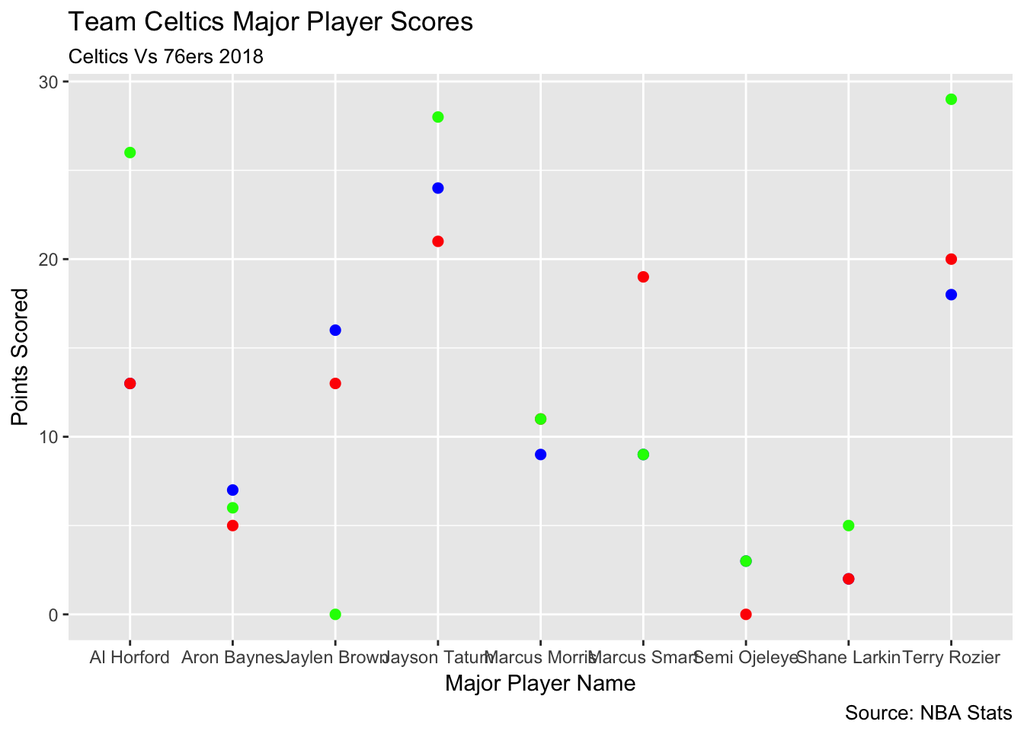

```r
# read file TeamCeltics.csv
data_total <- read.csv("TeamCeltics.csv")

# plot major players' scores in recent 3 games with 76ers
ggplot(data = data_total, aes(x = Player)) +
  geom_point(aes(y = Fifth_PTS), colour="blue", size = 2) +
  geom_point(aes(y = Third_PTS), colour="red", size = 2) +
  geom_point(aes(y = April_PTS), colour="green", size = 2) +
  labs(subtitle="Celtics Vs 76ers 2018",
       y="Points Scored",
       x="Major Player Name",
       title="Team Celtics Major Player Scores",
       caption = "Source: NBA Stats")
```

# 76ers Players Info 2018

Blue point: May 5th Game Red point: May 3rd Game Green point: April 30th Game

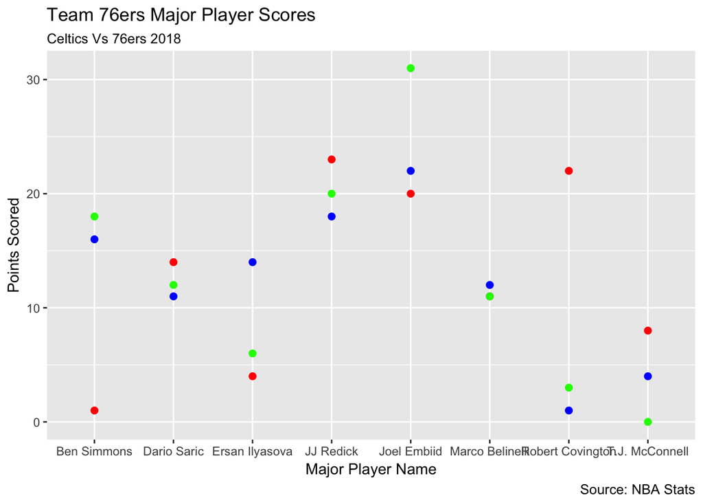

```r
# read file TeamSsixers.csv
data_total <- read.csv("TeamSsixers.csv")

# plot major players' scores in recent 3 games with Celtics
ggplot(data = data_total, aes(x = Player)) +
  geom_point(aes(y = Fifth_PTS), colour="blue", size = 2) +
  geom_point(aes(y = Third_PTS), colour="red", size = 2) +
  geom_point(aes(y = April_PTS), colour="green", size = 2) +
  labs(subtitle="Celtics Vs 76ers 2018",
       y="Points Scored",
       x="Major Player Name",
       title="Team 76ers Major Player Scores",
       caption = "Source: NBA Stats")
```

```r
#helper functions
getalltext <- function(file) {
  file_text <- readLines(file)
  file_text <- data_frame(line = 1:length(file_text), text = file_text)
  file_text <- file_text %>% unnest_tokens(word, text) %>%  anti_join(stop_words, by = "word")
  # Create a corpus from the collection of text files.
  file_text_corpus <- Corpus(VectorSource(file_text))
  # Remove punctuation
  file_text_corpus <- tm_map(file_text_corpus, removePunctuation)
  # Transform text to lower case
  file_text_corpus <- tm_map(file_text_corpus, content_transformer(tolower))
  # To remove some stopwords
  file_text_corpus <- tm_map(file_text_corpus, removeWords,c("twittercom","false"))
  file_text_corpus

}

getMostFreq <- function(x){
  # Build a term-document matrix
  file_2 <- TermDocumentMatrix(x)
  file_2 <- as.matrix(file_2)
  file_2 <- sort(rowSums(file_2),decreasing=TRUE)
  # Converting words to dataframe
  file_2 <- data.frame(word = names(file_2),freq=file_2)
  file_2
}
```

# Get the most Frequent words Before and After May 5th Game

```r
# Celtics WordCloud Before Game
celticsbefore_text <- getalltext("celticsbefore.txt")
celticsbeforewords <- getMostFreq(celticsbefore_text)
# Get table of most frequent words with frequency
head(celticsbeforewords, 15)
```

```
##                word freq
## celtics     celtics 4851
## sixers       sixers 1191
## 76ers         76ers  508
## boston       boston  400
## win             win  385
## 103             103  346
## series       series  326
## cavs           cavs  325
## 18139461   18139461  301
## refs           refs  300
## mcconnell mcconnell  221
## sweep         sweep  208
## beat           beat  188
## philly       philly  184
## team           team  175
```

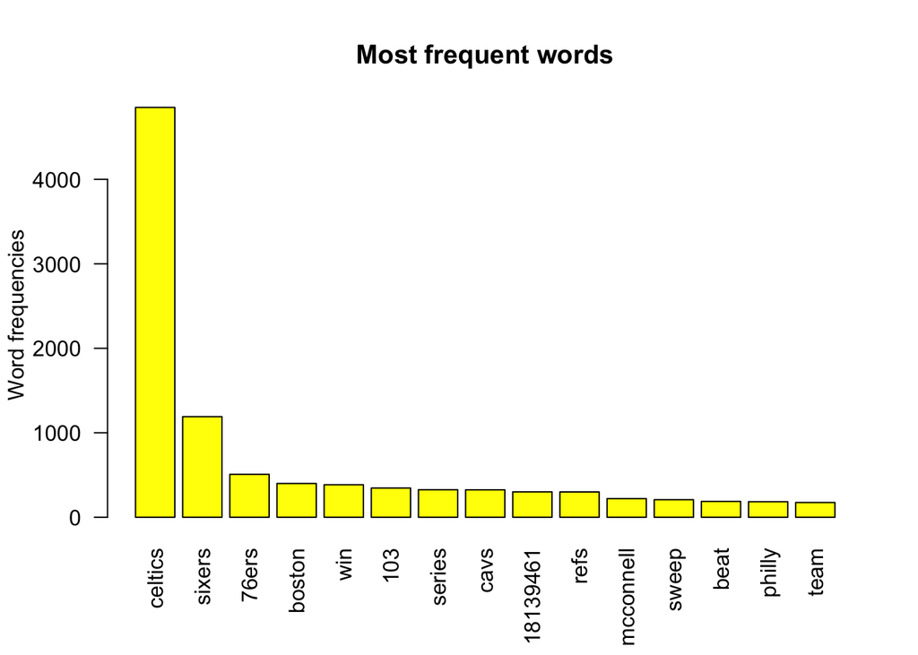

```r
# Draw bar plot of most frequent words with frequency
barplot(celticsbeforewords[1:15,]$freq, las = 2, names.arg = celticsbeforewords[1:15,]$word, col ="yellow", main ="Most frequent words",ylab = "Word frequencies")
```

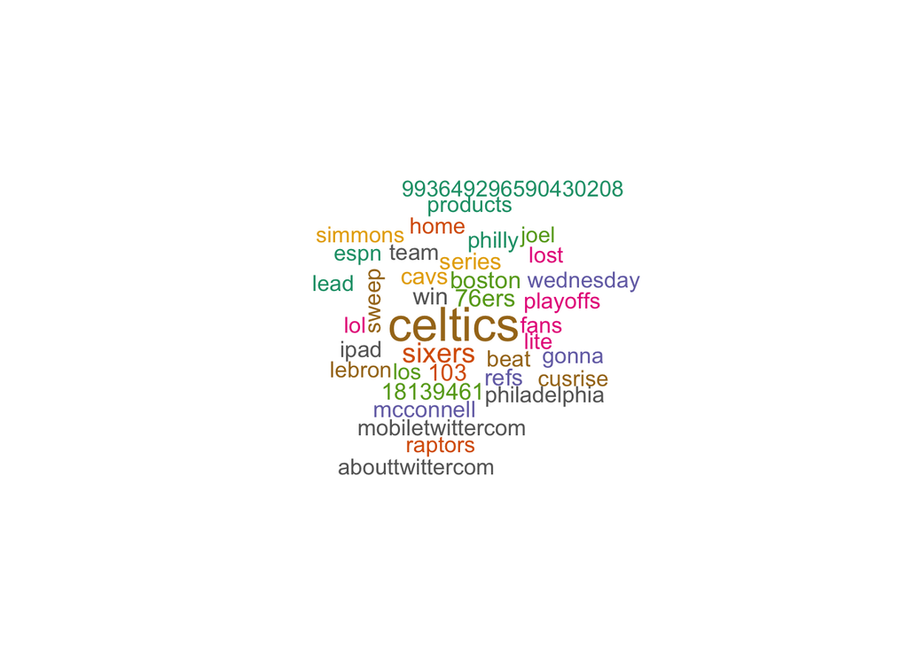

```r
set.seed(1234)
# Draw wordcloud for celtics before game
wordcloud(celticsbefore_text,min.freq=100,max.words=500,scale=c(2.2,1), colors=brewer.pal(8, "Dark2"),random.color=T, random.order=F)
```

```r
# 76ers WordCloud Before Game
ssixersbefore_text <- getalltext("ssixersbefore.txt")
ssixersbeforewords <- getMostFreq(ssixersbefore_text)
# Get table of most frequent words with frequency
head(ssixersbeforewords,15)
```

```
##                                  word freq
## sixers                         sixers 4954
## celtics                       celtics  970
## 16201775                     16201775  489
## win                               win  355
## stubhub                       stubhub  270
## series                         series  243
## philaunite                 philaunite  218
## 993535941426921472 993535941426921472  204
## nbaontnt                     nbaontnt  194
## boston                         boston  158
## abouttwittercom       abouttwittercom  157
## products                     products  157
## ipad                             ipad  154
## covington                   covington  149
## team                             team  149
```

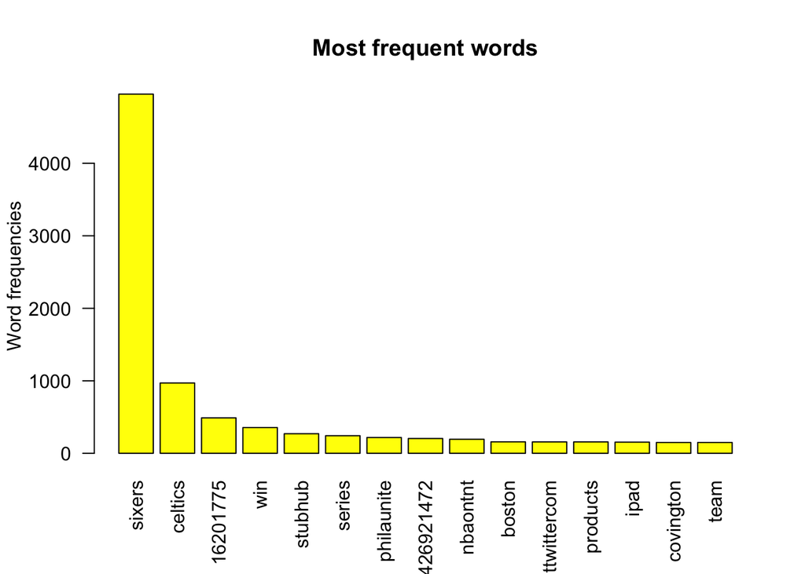

```r
# Draw bar plot of most frequent words with frequency
barplot(ssixersbeforewords[1:15,]$freq, las = 2, names.arg = ssixersbeforewords[1:15,]$word, col ="yellow", main ="Most frequent words",ylab = "Word frequencies")
```

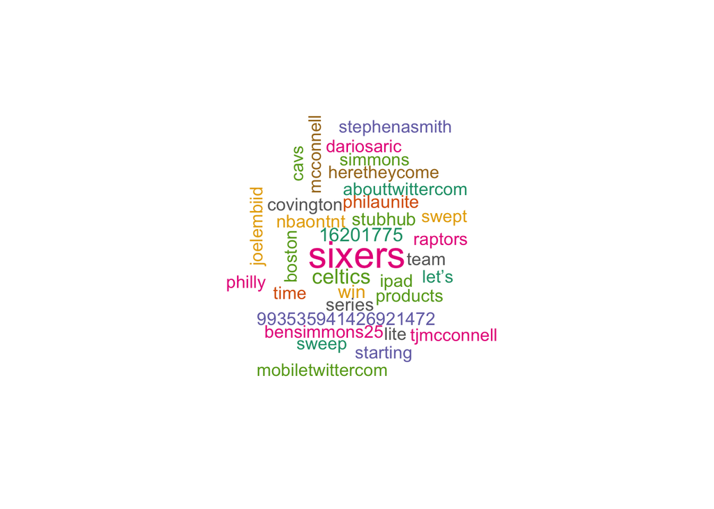

```r
set.seed(1234)
# Draw wordcloud for 76ers before game
wordcloud(ssixersbefore_text,min.freq=100,max.words=500,scale=c(2.2,1), colors=brewer.pal(8, "Dark2"),random.color=T, random.order=F)
```

```r
# Celtics WordClound After Game
celticsafter_text <- getalltext("celticsafter.txt")
celticsafterwords <- getMostFreq(celticsafter_text)
# Get table of most frequent words with frequency
head(celticsafterwords, 15)
```

```
##                            word freq
## celtics                 celtics 4014
## sixers                   sixers  886
## 76ers                     76ers  407
## boston                   boston  322
## cavs                       cavs  264
## cusrise                 cusrise  238
## sweep                     sweep  220
## raptors                 raptors  181
## series                   series  178
## nbaontnt               nbaontnt  171
## philadelphia       philadelphia  171
## abouttwittercom abouttwittercom  162
## products               products  162
## stephenasmith     stephenasmith  155
## let’s                     let’s  140
```

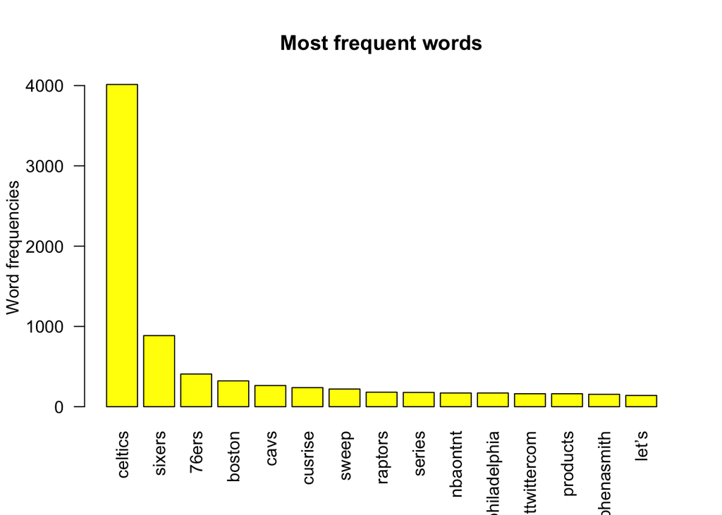

```r
# Draw bar plot of most frequent words with frequency
barplot(celticsafterwords[1:15,]$freq, las = 2, names.arg = celticsafterwords[1:15,]$word, col ="yellow", main ="Most frequent words",ylab = "Word frequencies")
```

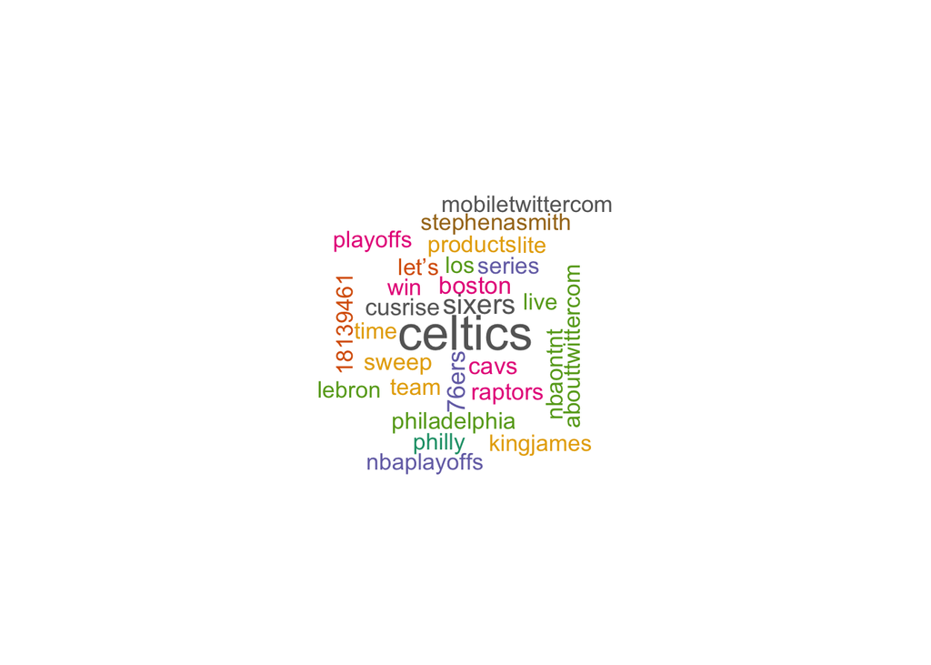

```r
set.seed(1234)
# Draw wordcloud for Celtics after game
wordcloud(celticsafter_text,min.freq=100,max.words=500,scale=c(2.2,1), colors=brewer.pal(8, "Dark2"),random.color=T, random.order=F)
```

```r
# 76ers WordCloud After Game
ssixersafter_text <- getalltext("ssixersafter.txt")
ssixersafterwords <- getMostFreq(ssixersafter_text)
# Get table of most frequent words with frequency
head(ssixersafterwords,15)
```

```
##                            word freq
## sixers                   sixers 4876
## celtics                 celtics 1026
## 16201775               16201775  367
## win                         win  328
## series                   series  241
## philaunite           philaunite  205
## nbaontnt               nbaontnt  186
## covington             covington  179
## abouttwittercom abouttwittercom  170
## products               products  170
## boston                   boston  166
## team                       team  155
## joelembiid           joelembiid  152
## time                       time  148
## bensimmons25       bensimmons25  147
```

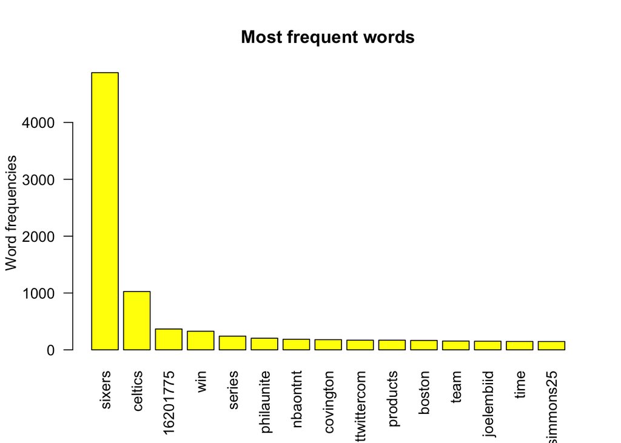

```r
# Draw bar plot of most frequent words with frequency
barplot(ssixersafterwords[1:15,]$freq, las = 2, names.arg = ssixersafterwords[1:15,]$word, col ="yellow", main ="Most frequent words",ylab = "Word frequencies")
```

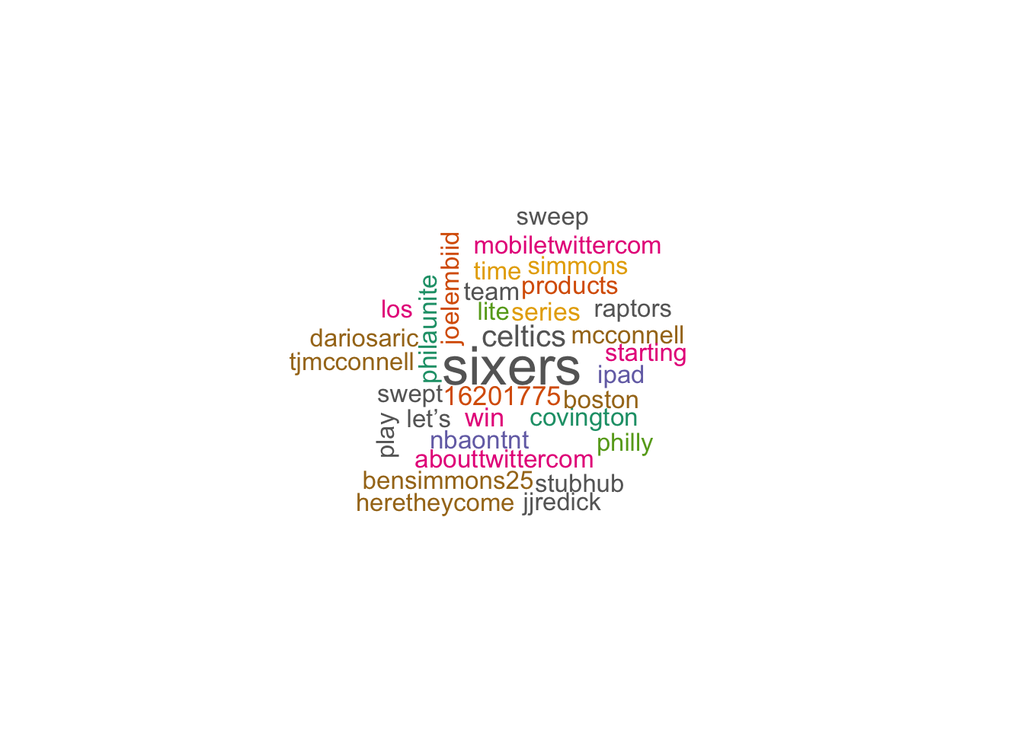

```r
set.seed(1234)
# Draw wordcloud for 76ers after game
wordcloud(ssixersafter_text,min.freq=100,max.words=500,scale=c(2.2,1), colors=brewer.pal(8, "Dark2"),random.color=T, random.order=F)
```

# Sentiment Analysis

```r
# Read txt files
celticsbefore <- read.delim("celticsbefore.txt", header=FALSE)
ssixersbefore <- read.delim("ssixersbefore.txt", header = FALSE)
celticsafter <- read.delim("celticsafter.txt", header=FALSE)
ssixersafter <- read.delim("ssixersafter.txt", header = FALSE)

# Converting text to dataframe
tidy_celticsbefore<- data_frame(paragraph = 149, text = as.character(celticsbefore$V1)) %>%
  unnest_tokens(word, text) %>%  anti_join(stop_words, by = "word")
tidy_ssixersbefore <- data_frame(paragraph = 112, text= as.character(ssixersbefore$V1)) %>%
  unnest_tokens(word, text) %>%  anti_join(stop_words, by = "word")
tidy_celticsafter<- data_frame(paragraph = 149, text = as.character(celticsafter$V1)) %>%
  unnest_tokens(word, text) %>%  anti_join(stop_words, by = "word")
tidy_ssixersafter <- data_frame(paragraph = 112, text= as.character(ssixersafter$V1)) %>%
  unnest_tokens(word, text) %>%  anti_join(stop_words, by = "word")

# bing type of celtics tweets before game
celticsbefore_sentiment <- tidy_celticsbefore %>%
  inner_join(get_sentiments("bing")) %>%
  count(word, sentiment, index = paragraph %/% 2) %>%
  spread(sentiment, n, fill = 0) %>%
  mutate(sentiment = positive-negative)
# bing type of celtics tweets after game
celticsafter_sentiment <- tidy_celticsafter %>%
  inner_join(get_sentiments("bing")) %>%
  count(word, sentiment, index = paragraph %/% 2) %>%
  spread(sentiment, n, fill = 0) %>%
  mutate(sentiment = positive-negative)
# bing type of 76ers tweets before game
ssixersbefore_sentiment <- tidy_ssixersbefore %>%
  inner_join(get_sentiments("bing")) %>%
  count(word, sentiment, index = paragraph %/% 3) %>%
  spread(sentiment, n, fill = 0) %>%
  mutate(sentiment = positive-negative)
# bing type of 76ers tweets after game
ssixersafter_sentiment <- tidy_ssixersafter %>%
  inner_join(get_sentiments("bing")) %>%
  count(word, sentiment, index = paragraph %/% 3) %>%
  spread(sentiment, n, fill = 0) %>%
  mutate(sentiment = positive-negative)
```

## Positive/negative words for Celtics tweets before May 5th game

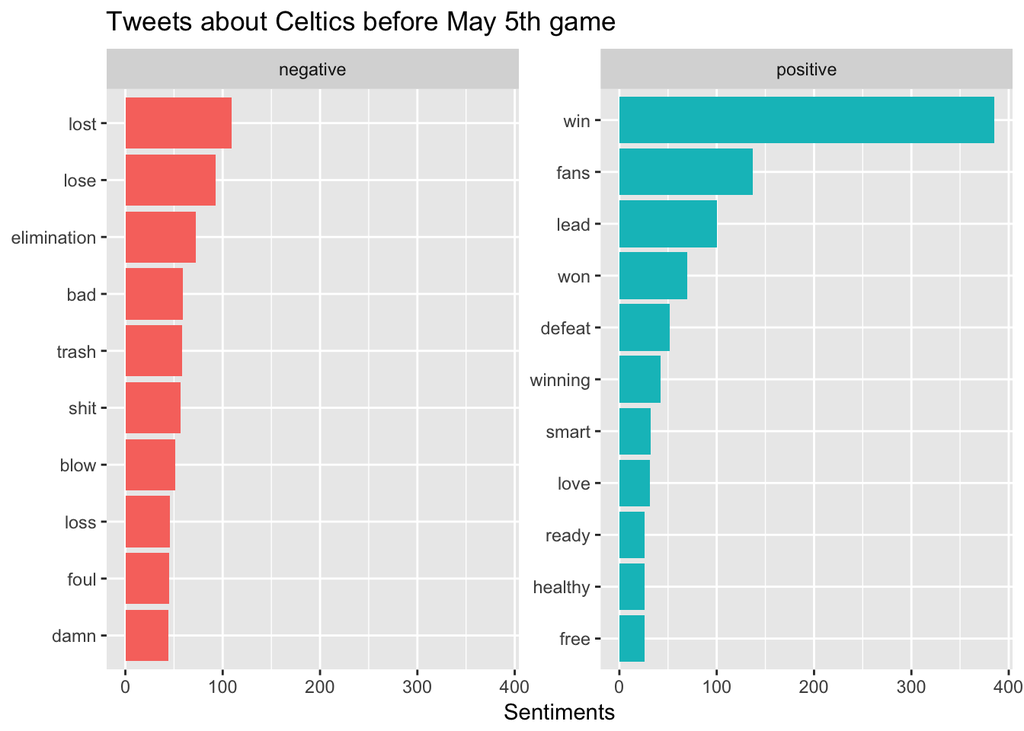

```r
celticsbefore_word_counts <- tidy_celticsbefore %>%
  inner_join(get_sentiments("bing")) %>%
  count(word, sentiment, sort = TRUE)

# Plot of Positive/Negative Tweets
celticsbefore_word_counts %>%
  group_by(sentiment) %>%
  top_n(10) %>%
  ungroup() %>%
  mutate(word = reorder(word, n)) %>%
  ggplot(aes(word, n, fill = sentiment)) +
  geom_col(show.legend = FALSE) +
  facet_wrap(~sentiment, scales = "free_y") +
  labs(y = "Sentiments",
       x = NULL) +
  ggtitle("Tweets about Celtics before May 5th game") +
  coord_flip()
```

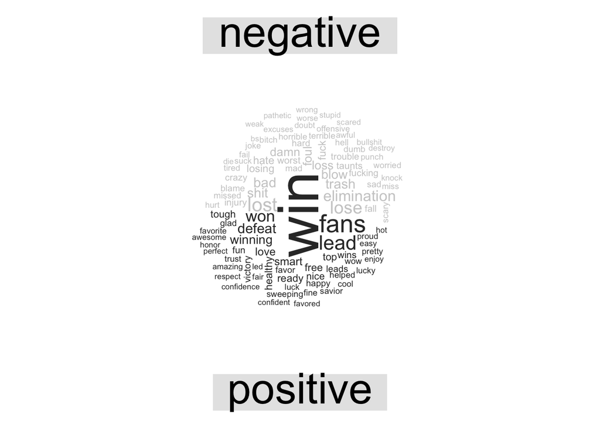

```r
# WordCloud of Positive/Negative Tweets
tidy_celticsbefore %>%
  inner_join(get_sentiments("bing")) %>%
  count(word, sentiment, sort = TRUE) %>%
  acast(word ~ sentiment, value.var = "n", fill = 0) %>%
  comparison.cloud(colors = c("gray80", "gray20"),
                   max.words = 100)
```

## Positive/negative words for Celtics tweets After May 5th game

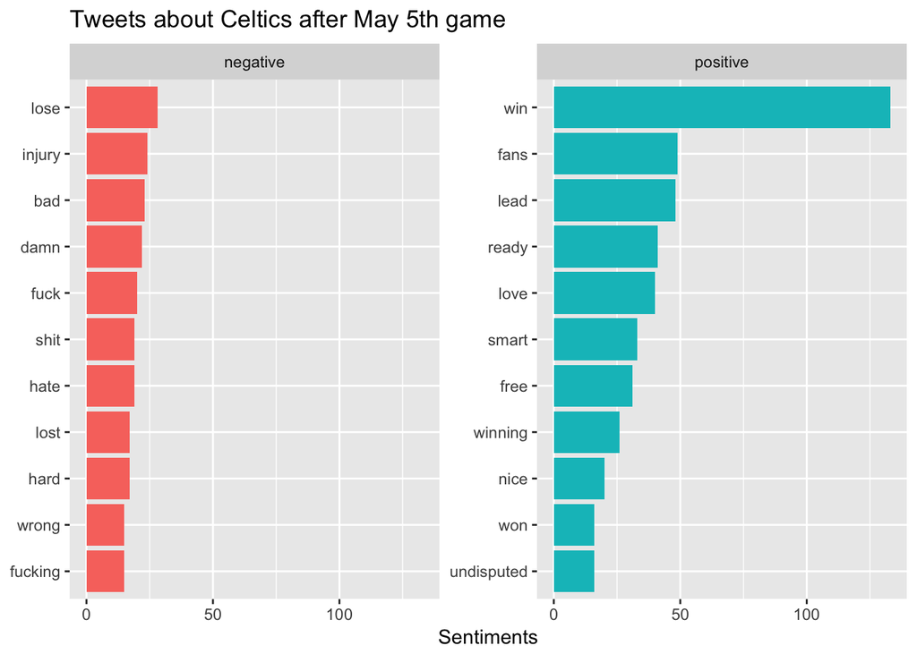

```r
celticsafter_word_counts <- tidy_celticsafter %>%
  inner_join(get_sentiments("bing")) %>%
  count(word, sentiment, sort = TRUE)

# Plot of Positive/Negative Tweets
celticsafter_word_counts %>%
  group_by(sentiment) %>%
  top_n(10) %>%
  ungroup() %>%
  mutate(word = reorder(word, n)) %>%
  ggplot(aes(word, n, fill = sentiment)) +
  geom_col(show.legend = FALSE) +
  facet_wrap(~sentiment, scales = "free_y") +
  labs(y = "Sentiments",
       x = NULL) +
  ggtitle("Tweets about Celtics after May 5th game") +
  coord_flip()
```

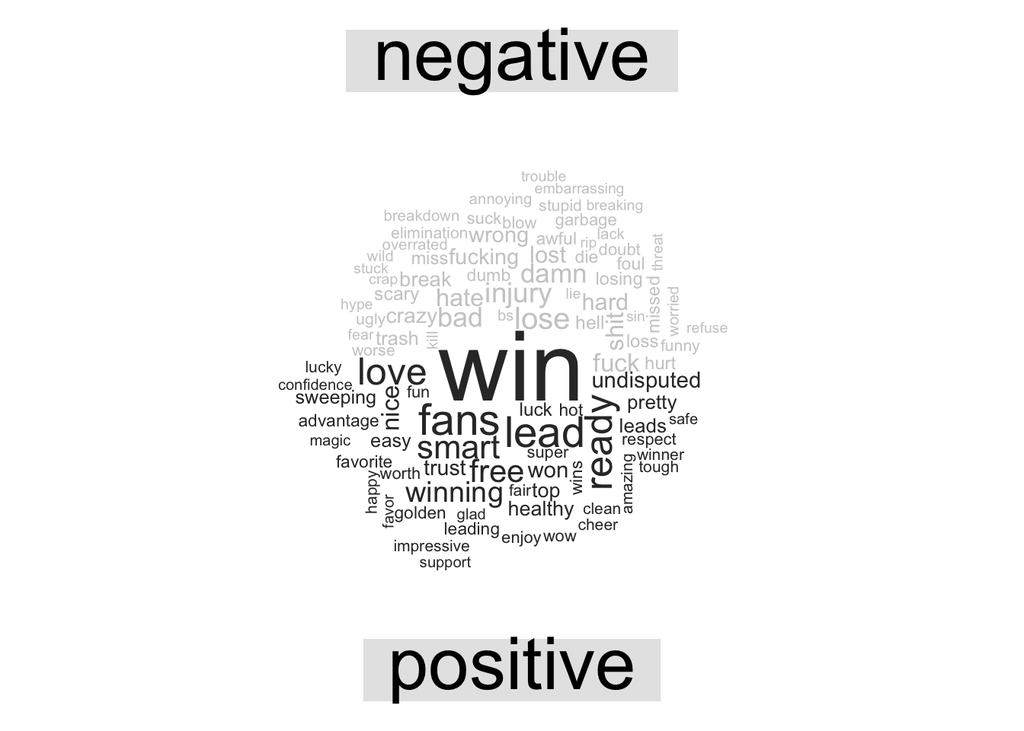

```r
# WordCloud of Positive/Negative Tweets
tidy_celticsafter %>%
  inner_join(get_sentiments("bing")) %>%
  count(word, sentiment, sort = TRUE) %>%
  acast(word ~ sentiment, value.var = "n", fill = 0) %>%
  comparison.cloud(colors = c("gray80", "gray20"),
                   max.words = 100)
```

## Positive/negative words for 76ers tweets before May 5th game

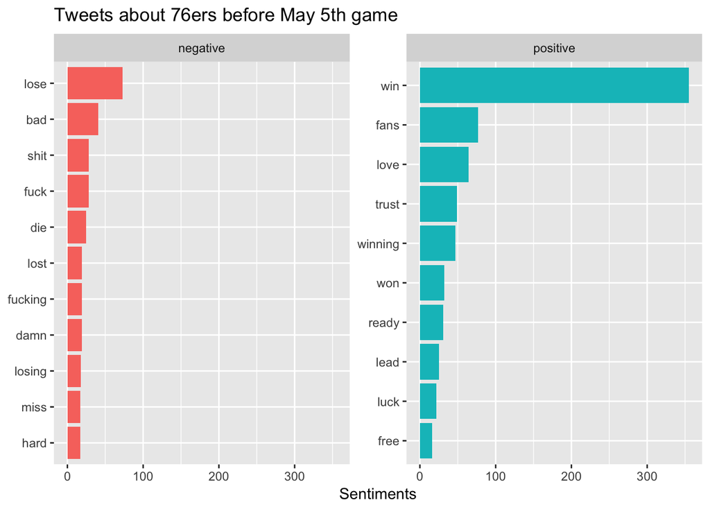

```r
ssixersbefore_word_counts <- tidy_ssixersbefore %>%
  inner_join(get_sentiments("bing")) %>%
  count(word, sentiment, sort = TRUE)

# Plot of Positive/Negative Tweets
ssixersbefore_word_counts %>%
  group_by(sentiment) %>%
  top_n(10) %>%
  ungroup() %>%
  mutate(word = reorder(word, n)) %>%
  ggplot(aes(word, n, fill = sentiment)) +
  geom_col(show.legend = FALSE) +
  facet_wrap(~sentiment, scales = "free_y") +
  labs(y = "Sentiments",
       x = NULL) +
  ggtitle("Tweets about 76ers before May 5th game") +
  coord_flip()
```

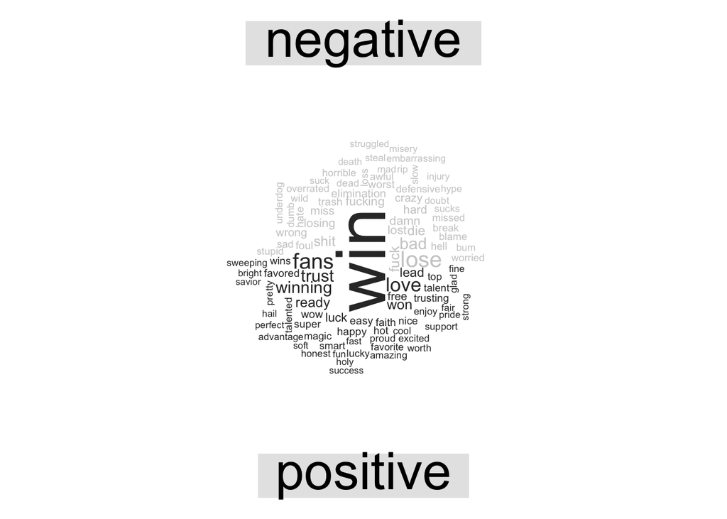

```r
# WordCloud of Positive/Negative Tweets
tidy_ssixersbefore %>%
  inner_join(get_sentiments("bing")) %>%
  count(word, sentiment, sort = TRUE) %>%
  acast(word ~ sentiment, value.var = "n", fill = 0) %>%
  comparison.cloud(colors = c("gray80", "gray20"),
                   max.words = 100)
```

## Positive/negative words for 76ers tweets after May 5th game

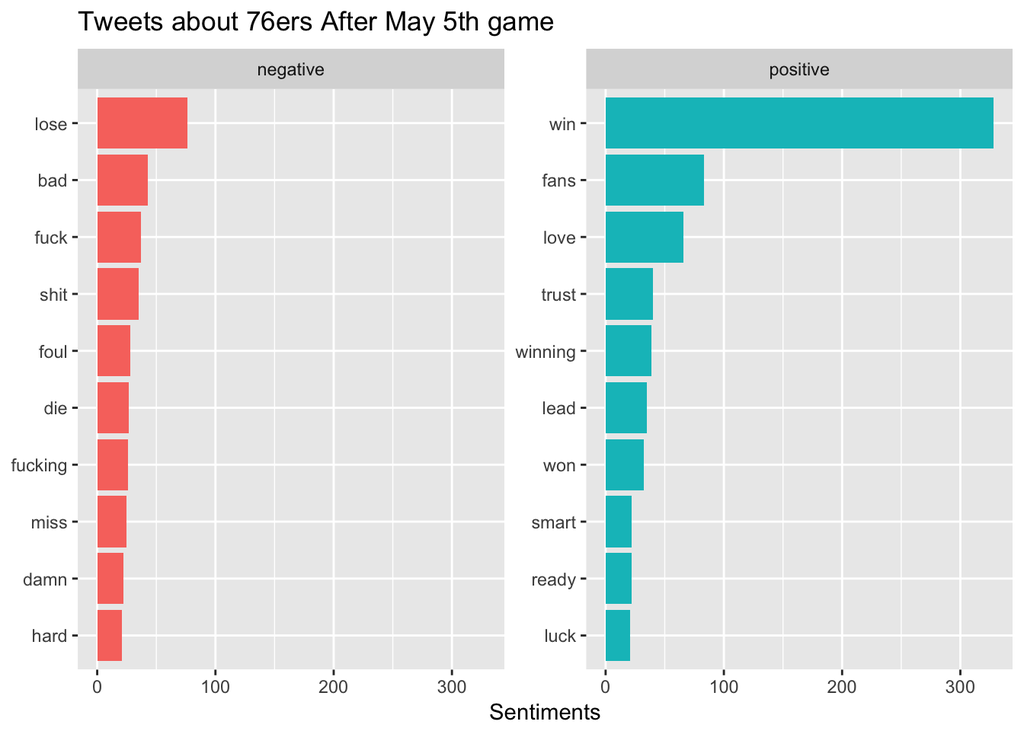

```r
ssixersafter_word_counts <- tidy_ssixersafter %>%
  inner_join(get_sentiments("bing")) %>%
  count(word, sentiment, sort = TRUE)

# Plot of Positive/Negative Tweets
ssixersafter_word_counts %>%
  group_by(sentiment) %>%
  top_n(10) %>%
  ungroup() %>%
  mutate(word = reorder(word, n)) %>%
  ggplot(aes(word, n, fill = sentiment)) +
  geom_col(show.legend = FALSE) +
  facet_wrap(~sentiment, scales = "free_y") +
  labs(y = "Sentiments",
       x = NULL) +
  ggtitle("Tweets about 76ers After May 5th game") +
  coord_flip()
```

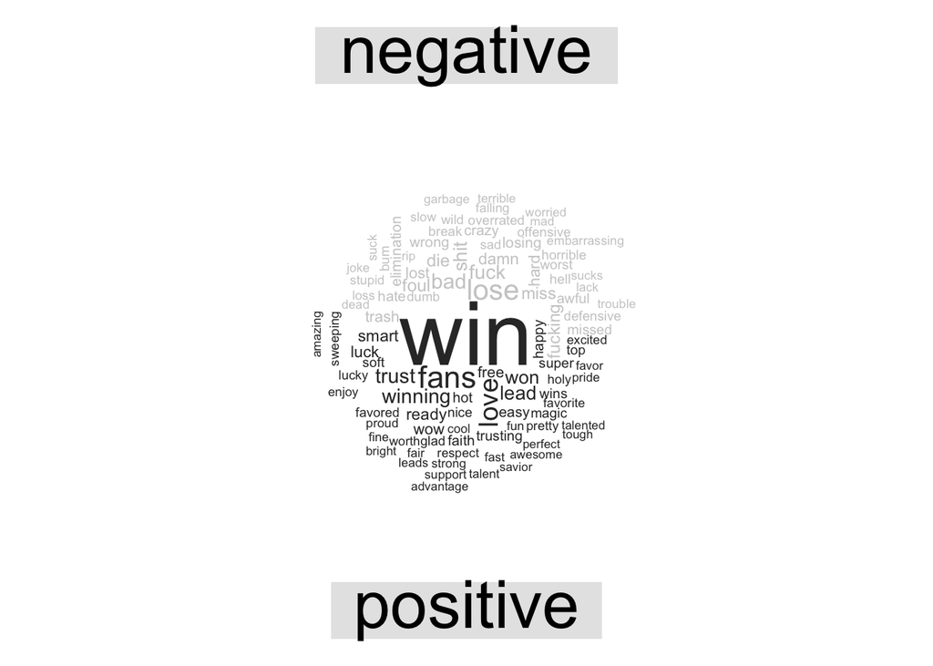

```r
# WordCloud of Positive/Negative Tweets
tidy_ssixersafter %>%
  inner_join(get_sentiments("bing")) %>%
  count(word, sentiment, sort = TRUE) %>%
  acast(word ~ sentiment, value.var = "n", fill = 0) %>%
  comparison.cloud(colors = c("gray80", "gray20"),
                   max.words = 100)
```